# Section 0 问题描述与完成项目流程

```
maze_size= (6, 6)
```

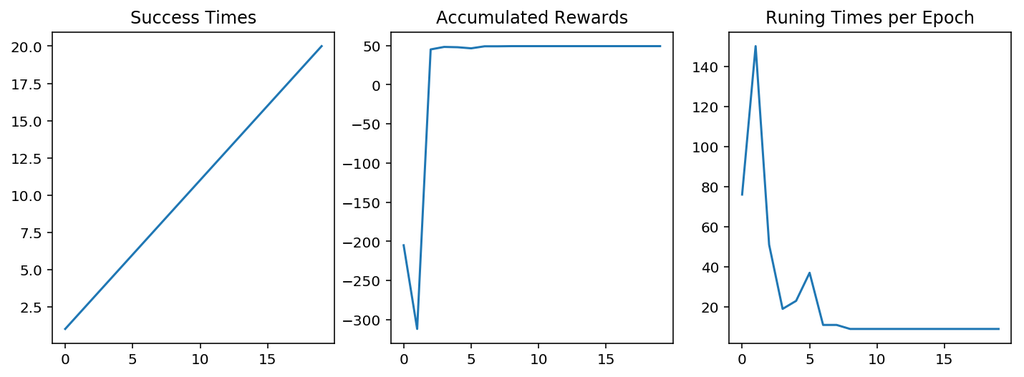

```
maze_size= (7, 7)
```

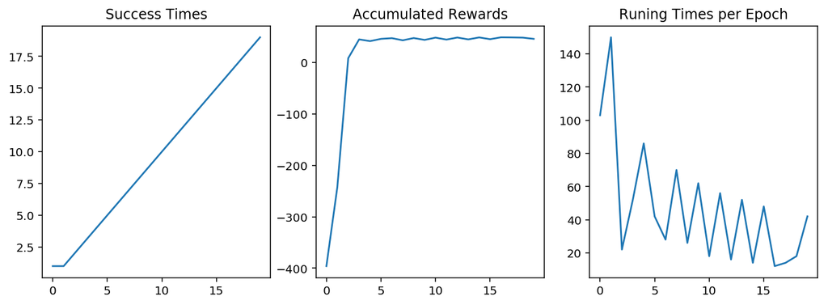

```
maze_size= (8, 8)
```

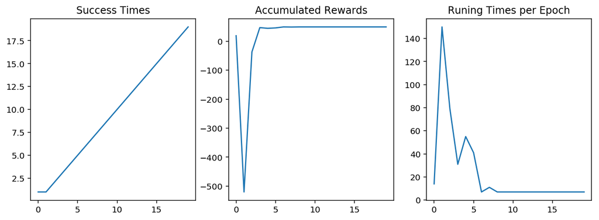

```
maze_size= (9, 9)
```

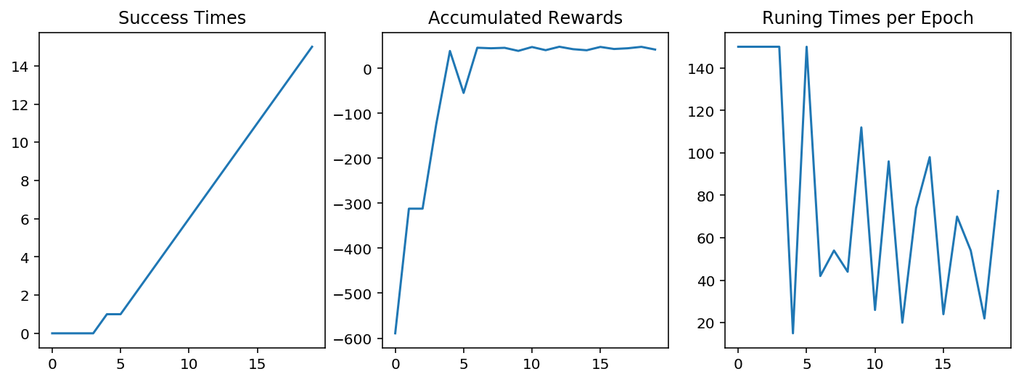

```
maze_size= (10, 10)
```

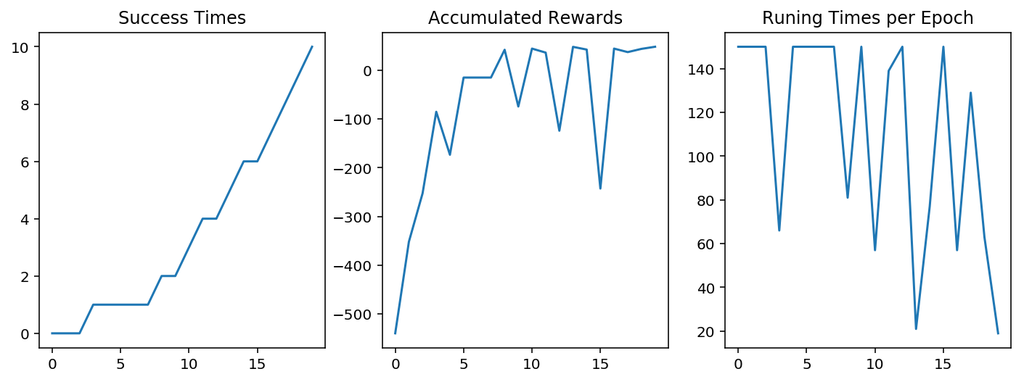

```
maze_size= (11, 11)
```

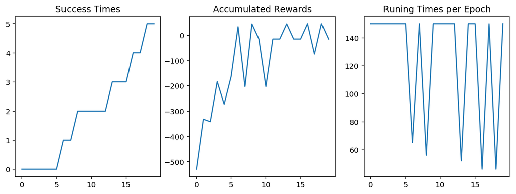

```
maze_size= (12, 12)
```

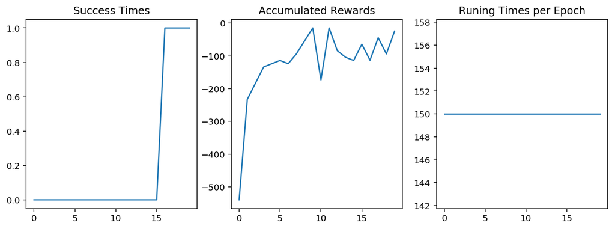

```python
# 调参 迷宫大小
epoch = 20
epsilon0 = 0.5
alpha = 0.5
gamma = 0.9
trap_number = 1

maze_sizes = [(6,6),(7,7),(8,8),(9,9),(10,10),(11,11),(12,12)]
for maze_size in maze_sizes:
    print ('maze_size=',maze_size)
    g = Maze(maze_size=maze_size,trap_number=trap_number)
    r = Robot(g,alpha=alpha, epsilon0=epsilon0, gamma=gamma)
    r.set_status(learning=True)

    runner = Runner(r, g)
    runner.run_training(epoch, display_direction=True)
    runner.plot_results()
```

```
epoch= 10
```

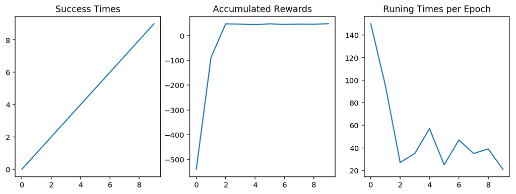

```
epoch= 15
```

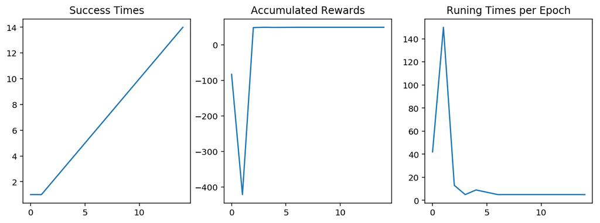

```
epoch= 20
```

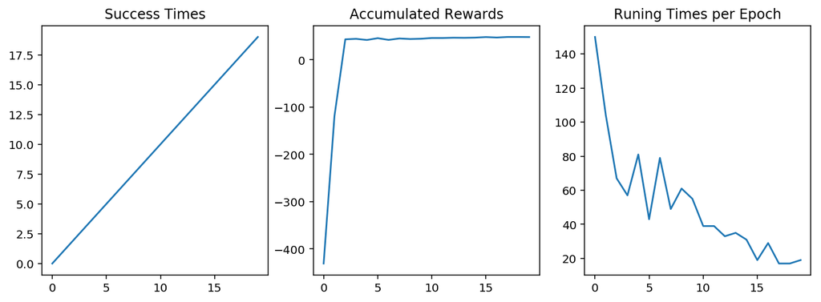

```
epoch= 25
```

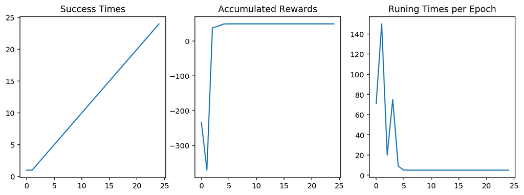

```python
# 调参 epoch
epsilon0 = 0.5
alpha = 0.5
gamma = 0.9
trap_number = 1
maze_size = (6,6)

epochs = [10,15,20,25]
for epoch in epochs:
    print ('epoch=',epoch)
    g = Maze(maze_size=maze_size,trap_number=trap_number)
    r = Robot(g,alpha=alpha, epsilon0=epsilon0, gamma=gamma)
    r.set_status(learning=True)

    runner = Runner(r, g)
    runner.run_training(epoch, display_direction=True)
    runner.plot_results()
```

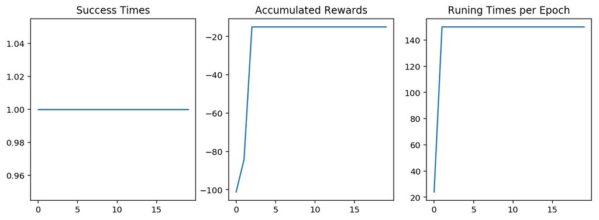

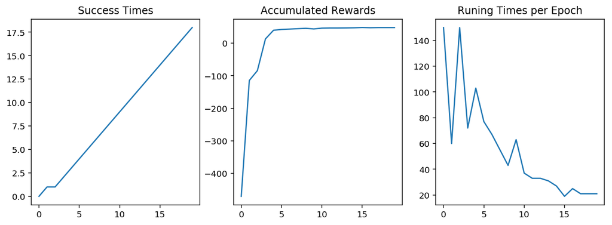

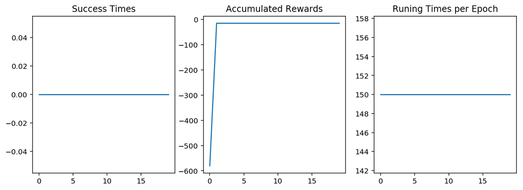

```python
# 调参 陷阱数
epoch = 20

epsilon0 = 0.5
alpha = 0.5
gamma = 0.9

maze_size = (6,6)
trap_numbers = [1,2,3]
for trap_number in trap_numbers:
    g = Maze(maze_size=maze_size,trap_number=trap_number)
    r = Robot(g,alpha=alpha, epsilon0=epsilon0, gamma=gamma)
    r.set_status(learning=True)

    runner = Runner(r, g)
    runner.run_training(epoch, display_direction=True)
    runner.plot_results()
```

# (回答区)

1.epsilon0 指的是机器人随机选择动作的概率，如果epsilon0的值太小，则有可能有的地方会探索不到；但是epsilon0的值太大，则后续会不稳定。  
我测试了从0.1-0.9的数值，从测试结果中来看，该数值在0.5左右时效果比较稳定, Accumulated Rewards很快可以获得最大奖励并没有在之后下降，Runing Times per Epoch在后续表现比较稳定。

2.alpha 是指一个学习速率，即对上一次学习和本次学习结果对一个权衡分析，alpha设置过低会导致机器人只在乎之前的知识，而不能积累新的reward。  
我测试了才能够0.1-0.9的数值，从测试结果上来看，该数值为0.5时效果比较稳定,Accumulated Rewards很快可以获得最大奖励并没有在之后下降，Runing Times per Epoch在后续表现比较稳定。

3.gamma 指的是折扣率，gamma值越大，表示越关注未来的奖励，如果gamma的值过小，则机器人很有可能无法学习到一个到达终点的策略。  
我测试了从0.85-0.99中的几个数值，我认为在0.9时可以达到不错的效果。

4.maze_sizes表示迷宫大小，epochs表示训练次数，两者应该同时考虑，因为maze_sizes值越大，往往需要更大epochs。  
从测试结果来看，在maze_sizes大小为(6,6)的情况下，epoch在15-20都可以达到很好的状态。  
在epoch为20的时候，迷宫大小设置为（12，12），发现无法得到一个训练结果，并不能收敛。即epson的数值对于一个大的迷宫而言，设置的过低了。

所以，最终的数值选择是： maze_size = (6,6)，trap_number=1，epoch = 20，epsilon0 = 0.5，alpha = 0.5，gamma = 0.9。

**问题 9：** 请将如下的文件打包，提交文件给审阅者。

- `robot.py`
- `robot_maze.ipynb`
- 由 `robot_maze.ipynb` 导出的 `robot_maze.html`